# ניתוח סקר מתמחים ברפואה

### 7.3 גורמים: משמעות אצל מחליפים

עמודות: נתוני הכשרה: האם החלפת התמחות; דירוג הבחירה: משמעות וסיפוק

**מבחן סטטיסטי:** t-test **מסקנה:** לא נמצא הבדל מובהק סטטיסטית (p=0.77).

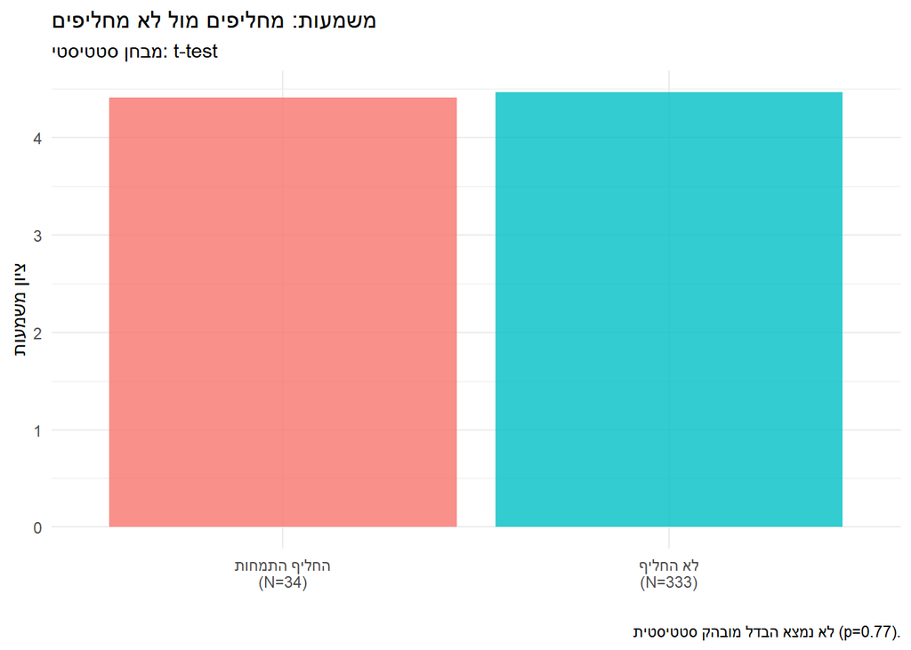

## 8 7. קווי אישיות מקצועיים

### 8.1 עבודה ידנית (כירורגיה מול לא)

*(הוצג בסעיף 4)*

### 8.2 קשר מתמשך עם מטופלים

עמודות: דירוג הבחירה: קשר עם מטופלים; נתוני הכשרה: סוג ההתמחות

היכן הקשר עם המטופלים משמעותי יותר?

**מבחן סטטיסטי:** ANOVA

**מסקנה:** נמצא הבדל/קשר מובהק סטטיסטית (p<0.001). הערכים הגבוהים ביותר נצפו בקבוצה: ‘פסיכיאטריה’.

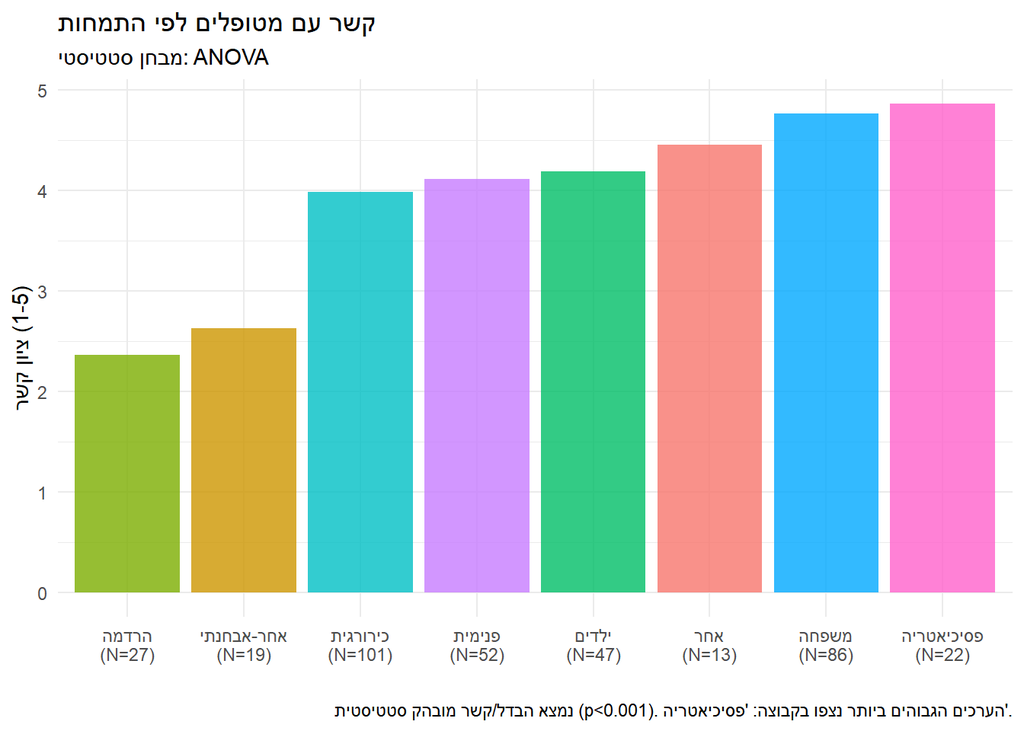

### 8.3 סטרס והתאמה

*(הוצג בסעיף 4)*

### 8.4 עבודת צוות (כירורגיה מול לא)

עמודות: דירוג הבחירה: עבודת צוות; נתוני הכשרה: קטגורית התמחות

האם עבודת הצוות נתפסת כחשובה יותר בכירורגיה?

**מבחן סטטיסטי:** t-test

**מסקנה:** נמצא הבדל/קשר מובהק סטטיסטית (p=0.03). הערכים הגבוהים ביותר נצפו בקבוצה: ‘כירורגית’.

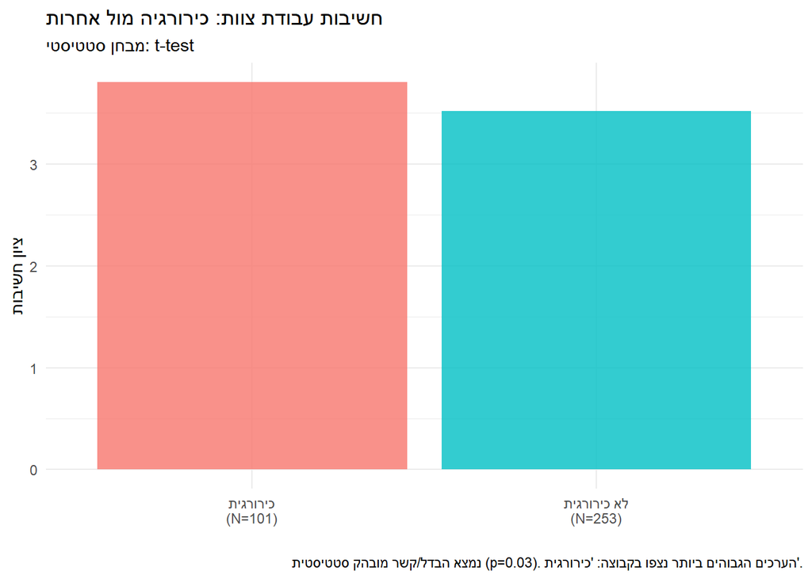

## 9 סיכום סטטיסטי מלא

### 9.1 הסבר על גודל אפקט (Effect Size)

גודל האפקט מודד את העוצמה המעשית של הממצאים, בנוסף למובהקות הסטטיסטית:

| מדד | זניח | קטן | בינוני | גדול |
| --- | --- | --- | --- | --- |
| **Cohen’s d** (t-test) | <0.2 | 0.2-0.5 | 0.5-0.8 | >0.8 |
| **Eta² (η²)** (ANOVA) | <0.01 | 0.01-0.06 | 0.06-0.14 | >0.14 |

### 9.2 נטל תורנויות (ANOVA)

```
##                  Df Sum Sq Mean Sq F value Pr(>F)
## Specialty_Group   7 1253.8  179.12   65.58 <2e-16 ***
## Residuals       351  958.6    2.73
## ---
## Signif. codes:  0 '***' 0.001 '**' 0.01 '*' 0.05 '.' 0.1 ' ' 1
```

### 9.3 רגרסיה לוגיסטית (ניבוי המלצה)

```
##
## Call:
## glm(formula = Recommend_Binary ~ Score_Satisfaction + Score_Balance +
##     Score_Bureaucracy + Shifts_Numeric, family = "binomial",
##     data = df_logit)
##
## Coefficients:
##                    Estimate Std. Error z value Pr(>|z|)
## (Intercept)        -4.88295    1.52931  -3.193  0.00141 **
## Score_Satisfaction  1.79301    0.28384   6.317 2.67e-10 ***
## Score_Balance       0.43173    0.19905   2.169  0.03009 *
## Score_Bureaucracy  -0.31726    0.20500  -1.548  0.12171
## Shifts_Numeric     -0.08624    0.09783  -0.882  0.37803
## ---
## Signif. codes:  0 '***' 0.001 '**' 0.01 '*' 0.05 '.' 0.1 ' ' 1
##
## (Dispersion parameter for binomial family taken to be 1)
##
##     Null deviance: 286.15  on 358  degrees of freedom
## Residual deviance: 189.96  on 354  degrees of freedom
## AIC: 199.96
##
## Number of Fisher Scoring iterations: 6
```

### 9.4 בדיקות VIF (קולינאריות)

```
## בדיקת VIF לרגרסיה הלוגיסטית:
## Score_Satisfaction      Score_Balance  Score_Bureaucracy     Shifts_Numeric
##           1.031531           1.238571           1.028209           1.219683
##
## פרשנות: VIF > 5 מצביע על בעיית קולינאריות בין המשתנים
```

### 9.5 בדיקות הנחות

#### 9.5.1 נורמליות (Shapiro-Wilk)

**Score_Satisfaction:** W=0.786, p<0.001 - ❌ לא נורמלי

**Score_Balance:** W=0.9006, p<0.001 - ❌ לא נורמלי

**Shifts_Numeric:** W=0.8823, p<0.001 - ❌ לא נורמלי

#### 9.5.2 שוויון שונויות (Levene)

**shifts_by_specialty:** p<0.001 - ❌ שונויות לא שוות

**colleagues_by_specialty:** p=0.32 - ✓ שונויות שוות